# Multidimensional Cholera Risk in Ethiopia: Analysis Using DHS 2019

Samuel Muluye

2025-07-01

# **INTRODUCTION**

## Background: Cholera as a Public Health Threat in Ethiopia

Cholera continues to pose a major public health threat in Ethiopia, especially in communities with inadequate access to clean water and proper sanitation facilities. As a waterborne disease, cholera flourishes in settings where water infrastructure is insufficient, sanitation systems are lacking, and hygiene practices are suboptimal. Limited access to safe drinking water and poor sanitation not only increase the risk of transmission but also hinder effective disease control. These challenges are often compounded by factors such as overcrowding, seasonal flooding, and population displacement, turning cholera outbreaks into urgent health and humanitarian crises.

Despite global progress in cholera control, Ethiopia continues to experience recurrent outbreaks, with disproportionately high burdens in rural and low-income households. Understanding the multidimensional risk factors, ranging from environmental conditions to socioeconomic disparities, is critical for designing effective, targeted interventions.

## Project Overview: Analyzing Cholera Risk Using DHS Data

This project examines the key drivers of cholera vulnerability using the 2019 Ethiopia Demographic and Health Survey (DHS), a nationally representative dataset that includes water and sanitation indicators as well as sociodemographic factors. By leveraging this comprehensive dataset, the project aims to:

1. **Assess cholera risk through composite indicators**: Constructing a Cholera Risk Score by integrating variables related to water access and sanitation.
2. **Identify high-risk populations**: Disaggregating risk by geographic region, urban/rural residence, and wealth quintiles to uncover disparities.
3. **Support evidence-based interventions**: Highlighting hotspots and structural inequities to guide public health planning.

By leveraging routine survey data like the DHS, this analysis moves beyond reactive outbreak response, supporting proactive, equity-focused public health strategies. The findings aim to contribute to Ethiopia’s broader cholera elimination efforts and the global roadmap for reducing cholera deaths by 90% by 2030.

# **METHODOLOGY AND APPROACH**

This analysis used data from the 2019 Ethiopia Demographic and Health Survey (DHS) to explore multidimensional cholera risk factors. Key variables included water sources, sanitation facilities, household wealth index, urban-rural residence, education level, and age of women. These variables were selected based on their relevance to cholera vulnerability and aligned with established WASH and socio-demographic indicators. Data were cleaned, recoded, and analyzed using descriptive statistics and visualization tools. A composite Cholera Risk Score was developed to quantify household-level vulnerability, incorporating unsafe water and poor sanitation indicators. Risk scores were then compared across regions, residence types, education levels, wealth quintiles, and age groups to identify patterns and high-risk populations. The analysis aimed to move beyond reactive outbreak responses by using routine survey data to guide proactive, equity-focused public health interventions.

# **SUMMARY OF KEY FINDINGS**

## Distribution of Socio-Demographic Characteristics Among Women Respondents

The socio-demographic profile shows that most respondents are young women, with over 40% aged 15–24. Education levels are low, as 41% have no formal schooling, and only 8.5% have higher education. The population is largely rural (66.8%). Regional representation is broad, led by Oromia, SNNPR, and Amhara. Wealth distribution is mixed, with 32.7% in the richest and 22.9% in the poorest quintiles, reflecting significant socio-economic disparities.

Table 1: Distribution of Socio-demographic Variables Among the Study Population

Frequency Table: Socio-Demographic Variables

| Variable | Category | Count | Percent (%) |
| --- | --- | --- | --- |
| Age Group | 15-19 | 2100 | 23.6 |
|  | 20-24 | 1578 | 17.8 |
|  | 25-29 | 1752 | 19.7 |
|  | 30-34 | 1166 | 13.1 |
|  | 35-39 | 1037 | 11.7 |
|  | 40-44 | 714 | 8.0 |
|  | 45-49 | 538 | 6.1 |
| Highest Education | no education | 3640 | 41.0 |
|  | primary | 3345 | 37.6 |
|  | secondary | 1149 | 12.9 |
|  | higher | 751 | 8.5 |
| Region | Addis Ababa | 818 | 9.2 |
|  | Afar | 641 | 7.2 |
|  | Amhara | 948 | 10.7 |
|  | Benishangul | 747 | 8.4 |
|  | Dire Dawa | 812 | 9.1 |
|  | Gambela | 723 | 8.1 |
|  | Harari | 763 | 8.6 |
|  | Oromia | 1052 | 11.8 |
|  | SNNPR | 1008 | 11.3 |
|  | Somali | 640 | 7.2 |
|  | Tigray | 733 | 8.2 |
| Residence | Rural | 5934 | 66.8 |
|  | Urban | 2951 | 33.2 |
| Wealth Index | poorest | 2031 | 22.9 |
|  | poorer | 1341 | 15.1 |
|  | middle | 1268 | 14.3 |
|  | richer | 1344 | 15.1 |
|  | richest | 2901 | 32.7 |

## Distribution of Water and Sanitation Access Among Households

Most households (37.9%) use pit latrines without a slab or open pits, and 31% have no toilet facility at all. Only a small proportion use improved sanitation, such as flush toilets (8.7%) or VIP latrines (2.6%). Regarding water sources, nearly 30% rely on public taps or standpipes, while 13.3% use surface water like rivers or ponds. Access to piped water is limited, with just 3.3% having it in their dwelling and 15.2% in their yard. Use of bottled or protected water sources remains relatively low, highlighting major gaps in access to safe water and sanitation.

Table 2: Distribution of Water and Sanitation Variables Among the Study Population

Frequency Table: WASH Variables

| Variable | Category | Count | Percent (%) |
| --- | --- | --- | --- |
| Toilet Type | flush to piped sewer system | 71 | 0.8 |
|  | flush to septic tank | 324 | 3.6 |
|  | flush to pit latrine | 298 | 3.4 |
|  | flush to somewhere else | 58 | 0.7 |
|  | flush, don't know where | 16 | 0.2 |
|  | ventilated improved pit latrine (vip) | 232 | 2.6 |
|  | pit latrine with slab | 1547 | 17.4 |
|  | pit latrine without slab/open pit | 3369 | 37.9 |
|  | no facility/bush/field | 2754 | 31.0 |
|  | composting toilet | 51 | 0.6 |
|  | bucket toilet | 3 | 0.0 |
|  | hanging toilet/latrine | 4 | 0.0 |
|  | other | 18 | 0.2 |
|  | not a dejure resident | 140 | 1.6 |
| Water Source | piped into dwelling | 292 | 3.3 |
|  | piped to yard/plot | 1349 | 15.2 |
|  | piped to neighbor | 330 | 3.7 |
|  | public tap/standpipe | 2623 | 29.5 |
|  | tube well or borehole | 343 | 3.9 |
|  | protected well | 348 | 3.9 |
|  | unprotected well | 433 | 4.9 |
|  | protected spring | 666 | 7.5 |
|  | unprotected spring | 700 | 7.9 |
|  | river/dam/lake/ponds/stream/canal/irrigation channel | 1180 | 13.3 |
|  | rainwater | 44 | 0.5 |
|  | tanker truck | 61 | 0.7 |
|  | cart with small tank | 13 | 0.1 |
|  | bottled water | 355 | 4.0 |
|  | other | 8 | 0.1 |
|  | not a dejure resident | 140 | 1.6 |

## Distribution of Cholera risk indicators by regions

The analysis reveals significant regional differences in cholera vulnerability. The table below presents the cholera risk score distribution across Ethiopia’s regions.

Table 3: The Distribution of Choler Risk Indicators by Region

Cholera Risk Indicators by Region

| Region | Mean Risk Score | Unsafe Water (%) | Poor Sanitation (%) |
| --- | --- | --- | --- |
| Addis Ababa | 0.2 | 5.6 | 16.6 |
| Afar | 1.4 | 55.7 | 85.3 |
| Amhara | 1.2 | 36.0 | 81.9 |
| Benishangul | 1.1 | 17.3 | 89.2 |
| Dire Dawa | 0.5 | 23.2 | 28.8 |
| Gambela | 1.2 | 30.7 | 89.2 |
| Harari | 0.6 | 19.3 | 45.5 |
| Oromia | 1.2 | 33.2 | 88.0 |
| SNNPR | 1.3 | 36.8 | 90.2 |
| Somali | 1.4 | 61.1 | 77.8 |
| Tigray | 1.0 | 25.1 | 73.4 |

The findings shows notable regional disparities in cholera risk across Ethiopia. Regions such as Afar, Somali, and SNNPR have the highest mean risk scores (≥1.3), driven by high levels of unsafe water sources and poor sanitation. Oromia, Amhara, Gambela, and Benishangul also show elevated risk scores above 1.0, with poor sanitation exceeding 80% in most.

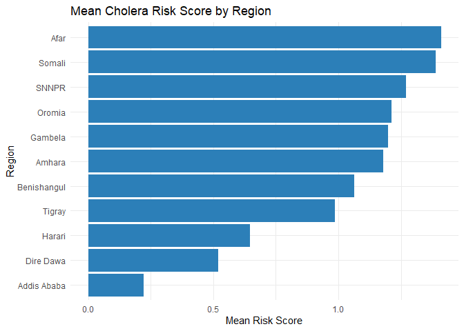

Figure 1: Mean Cholera Risk Scores Across Different Regions

In contrast, Addis Ababa report the lowest risk scores (0.2), reflecting better access to safe water and sanitation facilities. These patterns highlight the need for targeted WASH improvements in high-risk regions.

## Distribution of Cholera Risk Categories by Type of Residence

Rural areas have significantly higher counts in the High and Moderate risk categories compared to urban areas, which dominate the Low risk category. This suggests that rural populations face a greater cholera risk, possibly due to factors like limited access to clean water or healthcare.

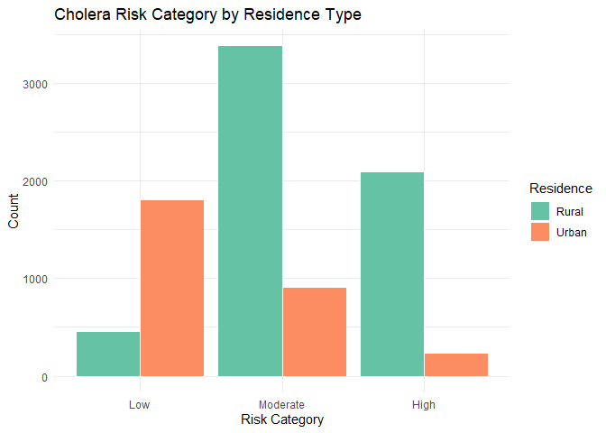

Figure 2: Graph Showing Cholera Risk Categories by Residence Type

## Distribution of Cholera Risk Scores by Wealth Index

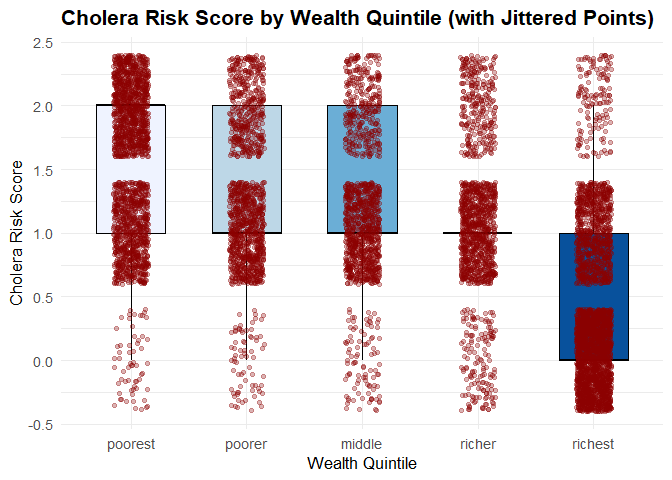

Figure 3: Boxplot Showing the Distribution of Cholera Risk Scores by Wealth Index

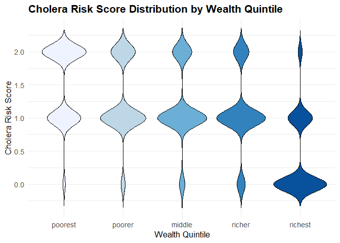

Figure 4: Violin Plot Showing the Distribution of Cholera Risk Scores by Wealth Index

## Education Level Predicts Cholera Risk: Higher Education Associated with Lower Vulnerability

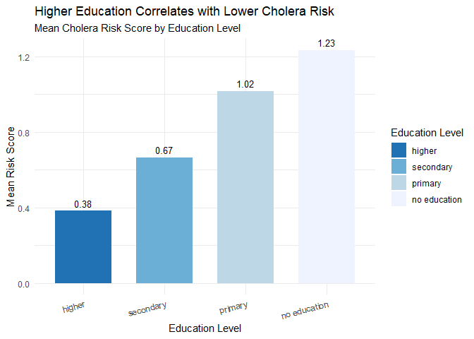

Figure 5: The Distribution of Choler Risk Score by Education Level

## Cholera Risk by Age Group and Education Level

The plot shows that individuals with no education have a higher cholera risk. Additionally, those in the lower age group appear more vulnerable than those in the higher age group.

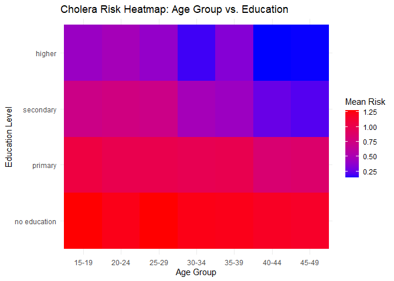

Figure 6: Heatmap Showing Cholera Risk by Age Group and Education Level

## Distribution of Cholera Risk Categories by Wealth Index Groups

The chart below shows a clear inverse relationship between wealth and cholera risk in Ethiopia.

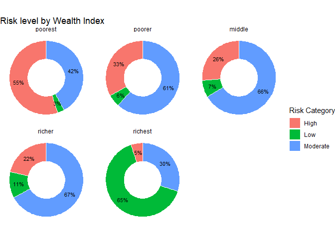

Figure 7: Donut Charts Showing the Distribution of Cholera Risk Categories by Wealth Index Groups

Among the poorest, 55% are in the high-risk category, while only 5% of the richest fall into this group. In contrast, the proportion of individuals in the low-risk category rises sharply with wealth, from just 3% among the poorest to 65% among the richest. Moderate risk is most common in the middle and richer groups. Overall, wealthier households are significantly less vulnerable to cholera, likely due to better access to clean water, sanitation, and healthcare services.

# **CONCLUSION**

This analysis demonstrates that cholera risk in Ethiopia is strongly associated with poor access to safe water and sanitation, low education levels, rural residence, and lower wealth quintiles. Regions such as Afar, Somali, and SNNPR exhibit consistently higher risk scores, indicating the need for targeted WASH (Water, Sanitation, and Hygiene) interventions. The findings also reveal that education and wealth can serve as protective factors, likely by improving awareness and access to hygiene resources. By leveraging DHS data and composite risk scoring, this project highlights vulnerable populations and geographic hotspots—providing valuable insights to guide public health planning and cholera prevention efforts in Ethiopia.